← Back to ML Fundamentals • Week 13 of 0–15

# Week 13 — ML Fundamentals

[Open in Colab](https://colab.research.google.com/github/sanketn26/learn-ml/blob/main/notebooks/week-13-saas.ipynb) [Open in VS Code](https://vscode.dev/github/sanketn26/learn-ml/blob/main/notebooks/week-13-saas.ipynb) Open in Jupyter [Download .ipynb](https://raw.githubusercontent.com/sanketn26/learn-ml/main/notebooks/week-13-saas.ipynb)

### 📝 How to Run This Notebook Locally

**1. Clone the repository:**  
`git clone https://github.com/sanketn26/learn-ml.git && cd learn-ml`

**2. Set up environment:**  
`python3 -m venv venv && source venv/bin/activate`  
`pip install jupyter notebook`

**3. Install course dependencies:**  
`pip install numpy pandas scikit-learn matplotlib scipy seaborn`  
`pip install torch`

**4. Open the notebook:**  
`jupyter notebook notebooks/week-13-saas.ipynb`

# Week 13 — CNNs: Sliding Detectors

**Course:** Applied ML Foundations for SaaS Analytics  
**Who this is for:** Engineers who have written a sliding-window loop, a regex, or an image filter.

A **Convolutional Neural Network** is not “the image one.” It is: **reuse a tiny detector at every position.**

## 🎯 What you will be able to do

- Picture a convolution as a small stencil sliding over a sequence or an image
- Explain weight sharing (“one detector, many places”) in one sentence
- Say what pooling does (downsample, keep the loudest hit)
- Train a tiny **1-D CNN** on CloudWave usage-over-time to predict churn
- Know when a CNN is the wrong tool (most SaaS tables)

**Think of it like… Ctrl+F with a fuzzy stencil, or a antivirus signature scan.**

You do not write a separate rule for “spike on Monday” and “spike on Thursday.” You write *one* “usage spike” detector and slide it along the week. The detector’s numbers are learned. That reuse is why CNNs have so few weights compared to a giant dense net on every pixel.

**Laptop budget**

No GPU. Aimed at ~8 GB RAM. Training uses a few thousand sampled customers (or short sequences) so this notebook should finish in a **few minutes on CPU**. The ideas are the same if you later set `n=None` and train on all 50k rows.

```python
%matplotlib inline
from pathlib import Path
import sys

import numpy as np
import pandas as pd
import matplotlib.pyplot as plt

# Make the shared style kit importable whether you launch from notebooks/ or repo root
for _p in [Path.cwd(), Path.cwd() / "notebooks", Path.cwd().parent]:
    if (_p / "course_style.py").exists():
        sys.path.insert(0, str(_p))
        break

from course_style import apply_style, setup_plots, find_data_dir

apply_style()
setup_plots()
DATA = find_data_dir()
print(f"Data folder: {DATA}")
print("Laptop mode: no GPU required. Models use a sample so each week finishes in a few minutes on CPU.")


try:
    import torch
    import torch.nn as nn
    import torch.nn.functional as F
except ImportError as exc:
    raise SystemExit("PyTorch is missing. Install with:  pip install torch") from exc

torch.manual_seed(0)
DEVICE = torch.device("cpu")
print("torch", torch.__version__, "device", DEVICE)
```

```
Data folder: /Users/sanketnaik/workspace/learn-ml/data
Laptop mode: no GPU required. Models use a sample so each week finishes in a few minutes on CPU.
```

```
torch 2.13.0 device cpu
```

## Visual: a 1-D filter sliding

```
usage by day:   [2, 2, 8, 9, 2, 2, 3]
detector:          [−1, 2, −1]     “a spike relative to neighbors”
slide:          pos0: 2·-1 + 2·2 + 8·-1 = -6
                pos1: 2·-1 + 8·2 + 9·-1 =  5   ← hit
                pos2: 8·-1 + 9·2 + 2·-1 =  8   ← hit
```

A **2-D CNN** is the same idea on a grid (a screenshot, a heatmap, an MRI). Same stencil, two axes.

**Engineer mental model**

`nn.Conv1d` is a 1-D convolution over time. `nn.Conv2d` is over height×width. `in_channels` is “how many parallel traces” (RGB = 3, or many features per day). `out_channels` is “how many different detectors we learn.” Pooling is `max` in a window — keep the strongest hit, throw away the exact timestamp.

```
findfont: Failed to find font weight semibold, now using 700.
```

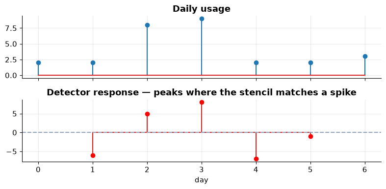

```
hits [-6.  5.  8. -7. -1.]
```

```python
# Hand-built spike detector — no learning yet
signal = np.array([2, 2, 8, 9, 2, 2, 3], dtype=float)
kernel = np.array([-1.0, 2.0, -1.0])
hits = np.convolve(signal, kernel, mode="valid")

fig, axes = plt.subplots(2, 1, figsize=(8, 4), sharex=True)
axes[0].stem(signal)
axes[0].set_title("Daily usage")
axes[1].stem(np.arange(1, 1 + len(hits)), hits, linefmt="#dc2626", markerfmt="ro")
axes[1].axhline(0, color="#94a3b8", ls="--")
axes[1].set_title("Detector response — peaks where the stencil matches a spike")
axes[1].set_xlabel("day")
plt.tight_layout()
plt.show()
print("hits", np.round(hits, 2))
```

## CloudWave: usage as a short time series

Each user becomes a length-T vector of weekly usage. The CNN’s job: “does this *shape* look like someone about to churn?” — not “what is their total.”

```python
from course_style import load_weekly_usage_grid

X, y = load_weekly_usage_grid(DATA)  # ~3k users × 12 weeks, CPU-friendly
print(f"users={len(X):,}  timesteps={X.shape[1]}  churn={y.mean():.3f}")

rng = np.random.default_rng(0)
idx = rng.permutation(len(X))
cut = int(0.8 * len(X))
tr, te = idx[:cut], idx[cut:]
Xtr, Xte, ytr, yte = X[tr], X[te], y[tr], y[te]
```

```
users=3,000  timesteps=12  churn=0.063
```

## A tiny Conv1d in PyTorch

`input` shape for Conv1d is `(batch, channels, time)`. We have one channel (usage).

```
UsageCNN(
  (conv): Conv1d(1, 8, kernel_size=(3,), stride=(1,), padding=(1,))
  (pool): AdaptiveMaxPool1d(output_size=1)
  (head): Linear(in_features=8, out_features=1, bias=True)
)
weights: 41
```

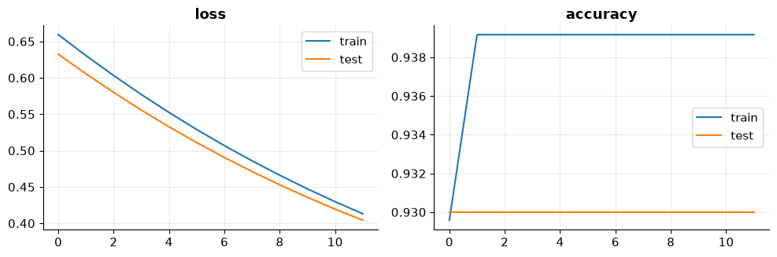

```
final test acc=0.930  (majority baseline ~0.930)
```

```python
class UsageCNN(nn.Module):
    def __init__(self, t: int):
        super().__init__()
        self.conv = nn.Conv1d(in_channels=1, out_channels=8, kernel_size=3, padding=1)
        self.pool = nn.AdaptiveMaxPool1d(1)   # loudest hit anywhere in the 12 weeks
        self.head = nn.Linear(8, 1)

    def forward(self, x):
        # x: (B, T) → (B, 1, T)
        h = F.relu(self.conv(x.unsqueeze(1)))
        h = self.pool(h).squeeze(-1)         # (B, 8)
        return self.head(h).squeeze(-1)      # (B,) logits


def run_epoch(model, xb, yb, opt=None):
    model.train(opt is not None)
    xb = torch.tensor(xb, dtype=torch.float32)
    yb = torch.tensor(yb, dtype=torch.float32)
    logits = model(xb)
    loss = F.binary_cross_entropy_with_logits(logits, yb)
    if opt is not None:
        opt.zero_grad()
        loss.backward()
        opt.step()
    with torch.no_grad():
        pred = (logits.sigmoid() > 0.5).float()
        acc = float((pred == yb).float().mean())
    return float(loss), acc


model = UsageCNN(Xtr.shape[1])
opt = torch.optim.Adam(model.parameters(), lr=1e-2)
print(model)
print("weights:", sum(p.numel() for p in model.parameters()))

hist = []
for epoch in range(12):
    tr_loss, tr_acc = run_epoch(model, Xtr, ytr, opt)
    te_loss, te_acc = run_epoch(model, Xte, yte, opt=None)
    hist.append((tr_loss, te_loss, tr_acc, te_acc))

hist = np.array(hist)
fig, axes = plt.subplots(1, 2, figsize=(10, 3.4))
axes[0].plot(hist[:, 0], label="train"); axes[0].plot(hist[:, 1], label="test")
axes[0].set_title("loss"); axes[0].legend()
axes[1].plot(hist[:, 2], label="train"); axes[1].plot(hist[:, 3], label="test")
axes[1].set_title("accuracy"); axes[1].legend()
plt.tight_layout()
plt.show()
print(f"final test acc={hist[-1, 3]:.3f}  (majority baseline ~{1 - yte.mean():.3f})")
```

## 2-D picture (so “CNN” in papers makes sense)

```
image  28×28
   │  3×3 stencil, 8 detectors
   ▼
feature maps  8 × 28 × 28     “where did detector #3 fire?”
   │  max-pool 2×2
   ▼
8 × 14 × 14
   │  flatten + linear
   ▼
class scores
```

Same four-line training step as Week 11. Only the *body* of `forward` changed.

**Watch out**

A CNN on 12 weekly totals is a teaching toy. Real CNNs earn their keep on *grids* (product screenshots, document scans) or long dense signals. For CloudWave’s 7-column table, last week’s GBT is still the right ship.

**Ship / don’t ship**

Ship a CNN when nearby positions *mean the same thing* (pixels, audio samples, equally spaced sensors). Do not ship one because a blog said “deep learning.”

## ✍️ Exercises

**1. Kernel size.** Change `kernel_size` to 5. Does test accuracy move? What did you make the detector look at?

**2. Dense baseline.** Flatten the 12 weeks into a `nn.Linear(12, 1)` and compare. If they tie, the *shape* was not the signal — the *total* was.

**3. Draw it.** Sketch one user as 12 boxes and a 3-wide stencil in three positions. Circle the position you think fires on a late-week drop.

## 🤔 Reflection

1. Why does weight sharing beat “a separate weight per day” on images?
2. What does max-pool throw away, and when is that a feature?
3. Would you CNN a one-hot `plan_type`? Why not?

## 🔗 Next week

RNNs: the stencil starts to have **memory**. We walk the sequence left to right and carry a clipboard.

← Previous Week Back to ML Fundamentals Next Week →